# Week 4: Model Evaluation and Selection

## Week 4 - Model Evaluation and Selection

EE0848

MACHINE LEARNING

for SP

## Last Week

Logistic Regression

## Today

Generalization

Data split (Training, Validation and Test)

Cross Validation

Hyperparameter Tuning

Performance Metrics and Model Evaluation

- We need to assess model performance to:
- Choose the best model among different options.

## Generalization: The Ultimate Goal

Generalization: A model’s ability to perform well on unseen data (data it was not trained on).

We want models that generalize well, not just memorize the training data.

Poor generalization leads to overfitting or underfitting.

[figure not shown]

## Overfitting and Underfitting

Overfitting:

The model learns the training data too well, including noise and outliers. Performs well on training data but poorly on unseen data. (High Variance)

Underfitting:

The model is too simple to capture the underlying patterns in the data. Performs poorly on both training and unseen data. (High Bias)

## The Bias-Variance Tradeoff

Bias: Error due to overly simplistic assumptions in the model (underfitting).

Variance: Error due to sensitivity to small fluctuations in the training data (overfitting).

Goal: Find the right balance between bias and variance to minimize the total error.

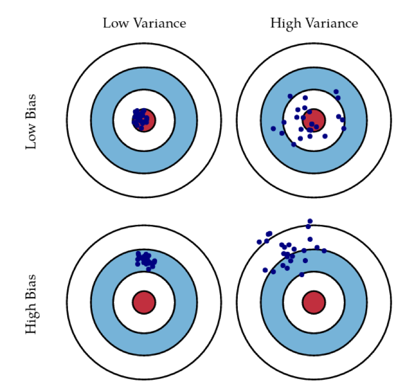

## So How Do We Ensure Generalization?

We know the goal is generalization, and that overfitting/underfitting (bias-variance tradeoff) threaten it.

But how do we detect these problems in practice?

We need to estimate how well our model performs on unseen data

We need to tune model complexity without biasing evaluation

We need a final, unbiased measure of performance

The answer: split the data into Training, Validation, and Test sets.

## Training, Validation, and Test Sets

## Training, Validation, and Test Sets

```python
from sklearn.model_selection import train_test_split
# Example data
X = ...
y = ...
# Split into train (60%) and temporary (40%)
X_train, X_temp, y_train, y_temp = train_test_split( X, y, test_size=0.4,                                                   random_state=42)
# Split the temporary set equally into validation (20%) and test (20%)
X_val, X_test, y_val, y_test = train_test_split(X_temp,y_temp, test_size=0.5,                                               random_state=42)
```

Training Set: Used to train the model.

Validation Set: Used to tune hyperparameters and select the best model.

Test Set: Used to evaluate the final model’s performance on completely unseen data.

## Why a Separate Test Set?

Avoids ‘cheating’ by using the same data for both model selection and final evaluation.

Provides an unbiased estimate of the model’s generalization performance.

Helps to ensure that the model will perform well in the real world.

## Stratified Splits

```python
from sklearn.model_selection import train_test_split
X_temp, X_test, y_temp, y_test = train_test_split(X, y, test_size=0.2,
random_state=123, stratify=y)
np.bincount(y_temp)
X_train, X_valid, y_train, y_valid = train_test_split(X_temp, y_temp, test_size=0.2,
random_state=123,stratify=y_temp)
print('Train size', X_train.shape, 'class proportions', np.bincount(y_train))
print('Test size', X_valid.shape, 'class proportions', np.bincount(y_valid))
print('Validation size', X_test.shape, 'class proportions', np.bincount(y_test))
```

Random Sampling does not make sure to keep the same class proportions in the train and test sets.

Stratification maintains the class distribution after the split.

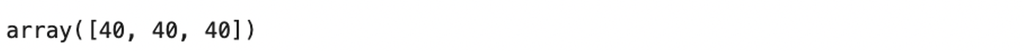

[figure not shown]

## Cross Validation

## Cross-Validation:

```python
# Define the model
model = LogisticRegression()
# Define 5-fold cross-validation
kfold = KFold(n_splits=5, shuffle=True, random_state=42)
# Compute cross-validation scores
scores = cross_val_score(model, X, y, cv=kfold, scoring='accuracy')
```

What if we don’t have enough data to create a separate validation set?

Cross-validation is a technique to evaluate model performance using the training data more effectively.

K-Fold Cross-Validation: The most common type.

## K-Fold Cross-Validation

Split the training data into equal-sized folds.

Average the performance metrics across the folds to get an overall estimate of the model’s performance.

## EE0848 - Machine Learning for SP

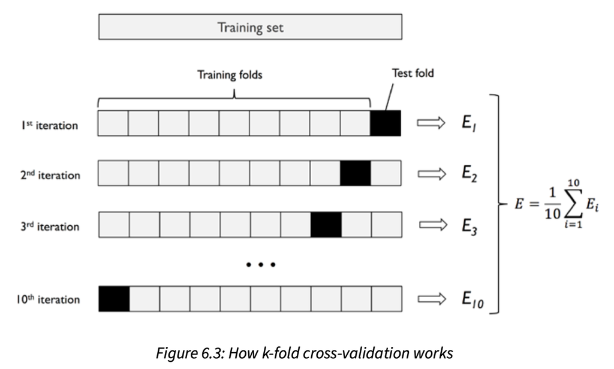

## Benefits of Cross-Validation

More reliable estimate of model performance than a single train/validation split.

Reduces the variance in the performance estimate.

Makes better use of limited data.

## Stratified K-Fold Cross-Validation

A variation of k-fold cross-validation that preserves the proportion of each class in each fold.

Important for classification problems, especially when dealing with imbalanced datasets.

## Hyperparameter Tuning

## Hyperparameter Tuning

Hyperparameters:

Parameters that are not learned by the model during training but are set beforehand.

Examples:

Learning rate in gradient descent

Number of trees in a random forest

Regularization strength (e.g., C in logistic regression)

Goal:

Find the optimal hyperparameter values that maximize the model’s performance on the validation set (or using cross-validation).

## Methods for Hyperparameter Tuning

Grid Search:

Exhaustively searches through a predefined set of hyperparameter values.

Random Search:

Randomly samples hyperparameter values from a specified distribution.

More advanced methods:

Bayesian optimization, gradient-based optimization.

## Learning Curves

Plots that illustrate model performance on training and validation sets as a function of model complexity (e.g., Decreasing Regularization Strength).

Help to diagnose bias and variance issues.

High bias (underfitting): Both training and validation errors are high.

High variance (overfitting): Training error is low, but validation error is high.

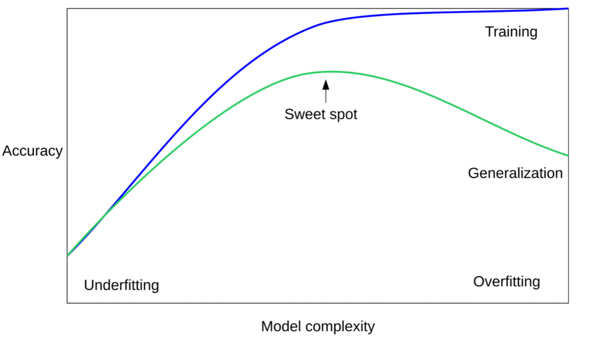

## Implementing Cross-Validation in Scikit-learn

cross_val_score() function:

model: The machine learning model.

X: The training data.

y: The target variable.

cv: The number of folds (e.g., cv=5 for 5-fold cross-validation) or a cross-validation splitter object (e.g., StratifiedKFold).

scoring: The performance metric to use (e.g., accuracy, precision, recall, f1, r2, neg_mean_squared_error).

Returns an array of scores for each fold.

## Example: cross_val_score (Code Snippet)

```python
from sklearn.model_selection import cross_val_score, KFold
from sklearn.linear_model import LogisticRegression
from sklearn.datasets import load_iris
# Load the iris dataset
iris = load_iris()
X, y = iris.data, iris.target
# Create a logistic regression model
model = LogisticRegression(max_iter=1000)
# Perform 5-fold cross-validation
scores = cross_val_score(model, X, y, cv=5, scoring='accuracy')
# Print the cross-validation scores
print(f"Cross-validation scores: {scores}")
print(f"Average cross-validation score: {scores.mean()}")
```

## Grid Search with Cross-Validation

Define a grid of hyperparameter values to explore.

For each combination of hyperparameter values:

Train the model using k-fold cross-validation.

Evaluate the model’s performance using the average cross-validation score.

Select the hyperparameter combination that yields the best cross-validation score.

## Implementing Grid Search with Cross-Validation in Scikit-learn

GridSearchCV class:

model: The machine learning model.

param_grid: A dictionary of hyperparameter values to search.

cv: The number of folds or a cross-validation splitter object.

scoring: The performance metric to use.

fit(X, y): Trains the models and finds the best hyperparameter combination.

best_params_: The best hyperparameter values found.

best_score_: The best cross-validation score achieved.

## Example:

```python
from sklearn.model_selection import GridSearchCV
from sklearn.ensemble import RandomForestClassifier
from sklearn.datasets import load_iris
# Create a random forest classifier
model = RandomForestClassifier()
# Define the hyperparameter grid
param_grid = {
'n_estimators': [50, 100, 200],
'max_depth': [None, 5, 10, 20],
'min_samples_split': [2, 5, 10] }
# Perform grid search with cross-validation
grid_search = GridSearchCV(model, param_grid, cv=5, scoring='accuracy')
grid_search.fit(X, y)
# Print the best hyperparameters and the best score
print(f"Best hyperparameters: {grid_search.best_params_}")
print(f"Best cross-validation score: {grid_search.best_score_}")
```

## Performance Metrics

## Performance Metrics: Regression

Mean Squared Error (MSE): Average squared difference between predicted and actual values.

Root Mean Squared Error (RMSE): Square root of MSE (more interpretable, same units as the target variable).

Mean Absolute Error (MAE): Average absolute difference between predicted and actual values (less sensitive to outliers than MSE).

R-squared (Coefficient of Determination): Proportion of variance in the target variable explained by the model.

## Performance Metrics: Regression

**MSE (Mean Squared Error): lower is better**

## Performance Metrics: Classification

Accuracy: Overall correctness of the model.

Precision: Proportion of true positives among predicted positives.

Recall: Proportion of true positives among actual positives.

F1-score: Harmonic mean of precision and recall.

ROC: Receiver Operating Characteristic curve.

AUC: Area under the ROC Curve

## Confusion Matrix

A table that summarizes the performance of a classification model.

Provides a more detailed breakdown of the model’s predictions than just accuracy.

Helps to identify which classes the model is confusing.

Positive and Negative are arbitrary (minority class chosen to be the positive class more frequently)

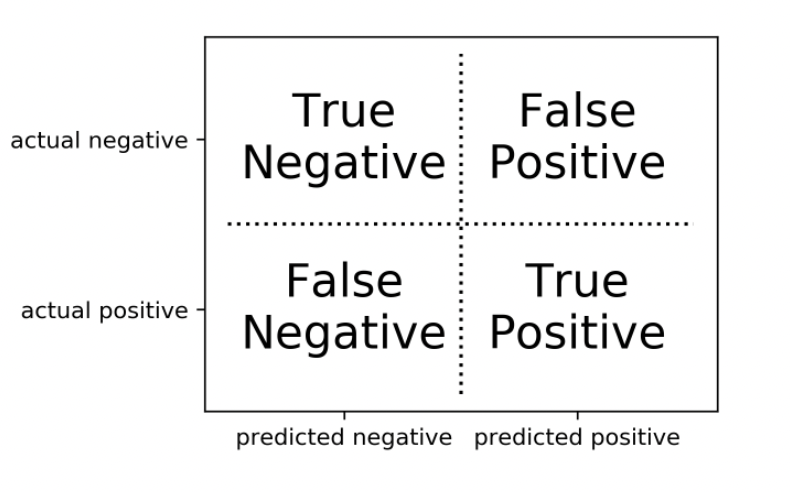

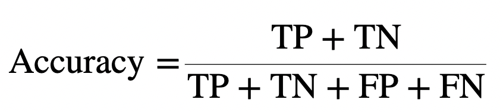

## EE0848 - Machine Learning for SP

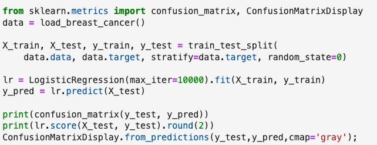

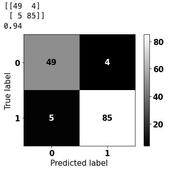

## Problems with Accuracy

Data with 90% negatives:

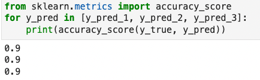

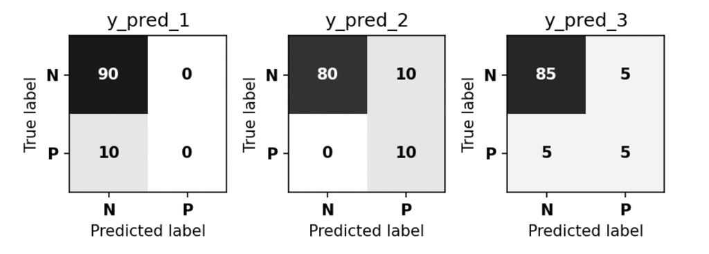

## Precision, Recall, f-score

Positive Predictive Value (PPV)

Sensitivity, covarage, true positive rate

Harmonic mean of precision and recall

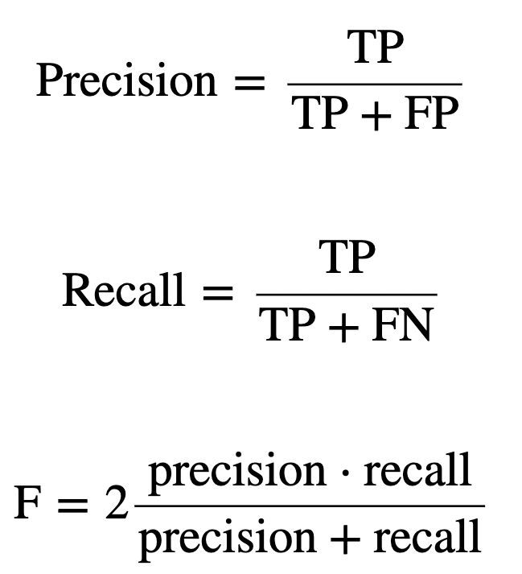

## Precision-Recall Tradeoff (Revisited)

Often, increasing precision leads to decreasing recall, and vice versa.

The optimal balance depends on the specific application.

Example:

Spam detection: High precision is more important.

High False Positive ratio (bad precision), incorrectly classifying an email as Spam can cause important email to be missed.

HIV test (Positive vs Negative)

High False negative (bad recall), incorrectly classiying an HIV positive patient as negative can cause a lot of problem,

Delay in treatment, Spread of disasse etc.

## Changing Thresholds

```python
In the first classification report (y_pred = lr.predict(X_test)), the model uses its default threshold of 0.5.
High accuracy and high precision for the “False” class suggest the model is very conservative about predicting “True.”
The recall for “True” is relatively lower because the model only labels an instance as “True” when it’s highly confident.
```

More samples are now classified as “True,” which typically increases recall for the “True” class (fewer positives are missed).

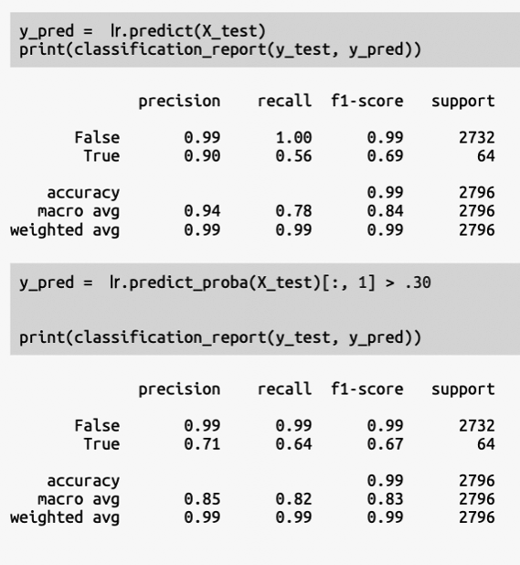

## Precision-Recall Curve

A plot that shows the trade-off between precision and recall across different probability thresholds in a binary classification model.

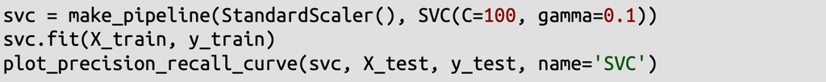

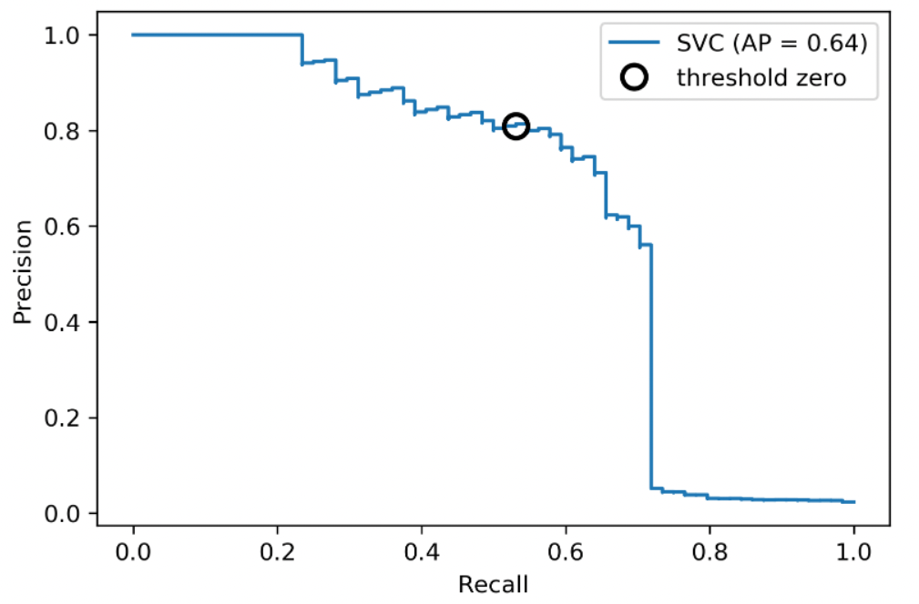

## ROC Curve

A plot that shows the True Positive Rate (TPR) versus the False Positive Rate (FPR) at various classification thresholds for a binary classifier

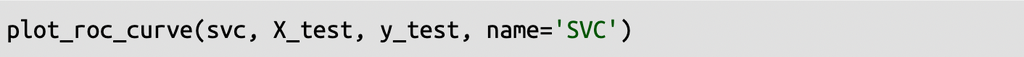

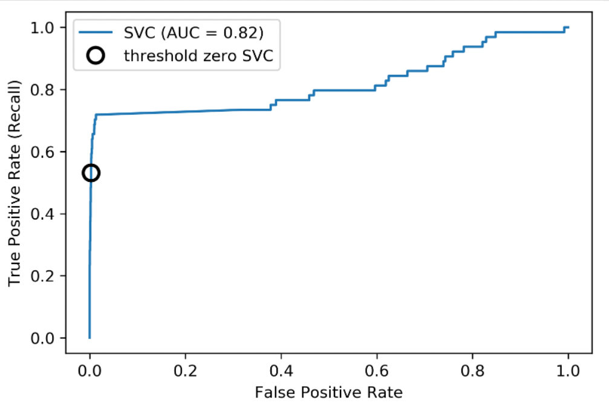

## Area Under ROC Curve (AUC)

Typically refers to the area under the ROC (Receiver Operating Characteristic) curve (sometimes under the Precision-Recall curve).

It provides a single metric that summarizes a classifier’s performance across all possible thresholds.

A perfect classifier has an AUC of 1, while a completely random classifier has an AUC of 0.5.

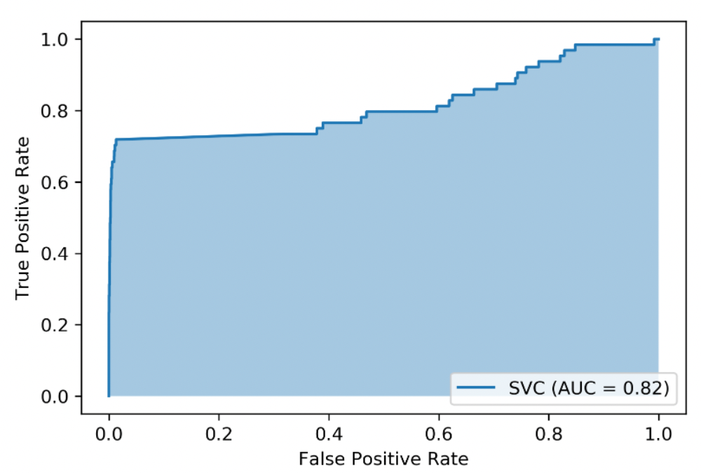

## Summary and Key Takeaways

Model evaluation is essential for building effective machine learning models.

Use appropriate metrics to assess model performance.

Split your data into training, validation, and test sets.

Use cross-validation to get a more reliable estimate of model performance.

Tune hyperparameters to optimize your model.

Be aware of the bias-variance tradeoff.